# A centre-peripheral comparison of police statements from central areas in Groningen

Leon Wetzel

24-3-2020

## Introduction

In this report, we take an in-depth look at the police statements from the city of Groningen. Before we get started, we load the data file that has been generated by the support application, written in Python. As described in the application’s documentation, it downloads the original CSV file from the open data portal of the Municipality of Groningen and transforms it for use with R.

```r
library('readxl')

data <- read_excel("data.xlsx", col_types = c("text",
    "text", "numeric", "numeric", "numeric",
    "numeric", "numeric", "numeric", "numeric",
    "numeric", "numeric", "numeric", "numeric",
    "numeric", "numeric", "numeric", "numeric",
    "numeric", "numeric", "numeric", "numeric",
    "numeric", "numeric", "numeric", "numeric",
    "numeric", "numeric", "numeric", "numeric",
    "numeric", "numeric", "numeric", "numeric",
    "numeric", "numeric", "numeric", "numeric", "text"))

data <- data.frame(data)
```

We start off by taking a look at the data. The first two columns describe the various neighbourhoods of Groningen. The dataset has been limited by the 28 neighbourhoods that are relevant for this study; these are areas that can be designated as either a centre area or a non-centre area. As can be seen below, there are 8 city sections which belong to the city centre of Groningen and 20 sections that belong to the outer-centre area.

```r
table(data$area)
```

```
##
##       centre outer_centre
##            8           20
```

## Comparing burglary numbers between 2014 and 2015

For comparing the amount of statements involving burglary in 2014 and 2015, we want to perform a paired $t$-test. Before we perform the test, we take a look at the distribution of the numbers and we perform the Shapiro-Wilk test to check if the data is normally distributed.

### Checking the assumptions

As mentioned in the introduction of this chapter, we need to investigate whether or not it is appropriate to use the paired $t$-test. We therefore take a look at several assumptions that we need to meet in order to use the paired $t$-test.

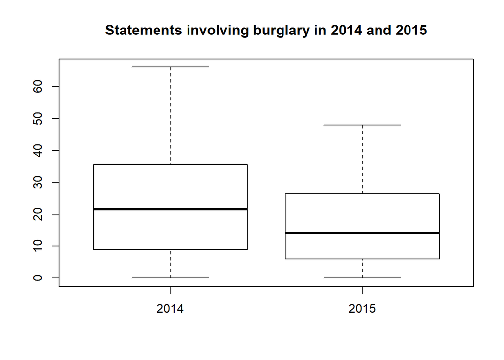

```r
boxplot(data$diefstal_af_uit_woning_2014, data$diefstal_af_uit_woning_2015, main="Statements involving burglary in 2014 and 2015", names=c("2014", "2015"))
```

```r
shapiro.test(data$diefstal_af_uit_woning_2014)
```

```
##
##  Shapiro-Wilk normality test
##
## data:  data$diefstal_af_uit_woning_2014
## W = 0.94485, p-value = 0.1468
```

```r
shapiro.test(data$diefstal_af_uit_woning_2015)
```

```
##
##  Shapiro-Wilk normality test
##
## data:  data$diefstal_af_uit_woning_2015
## W = 0.90661, p-value = 0.0164
```

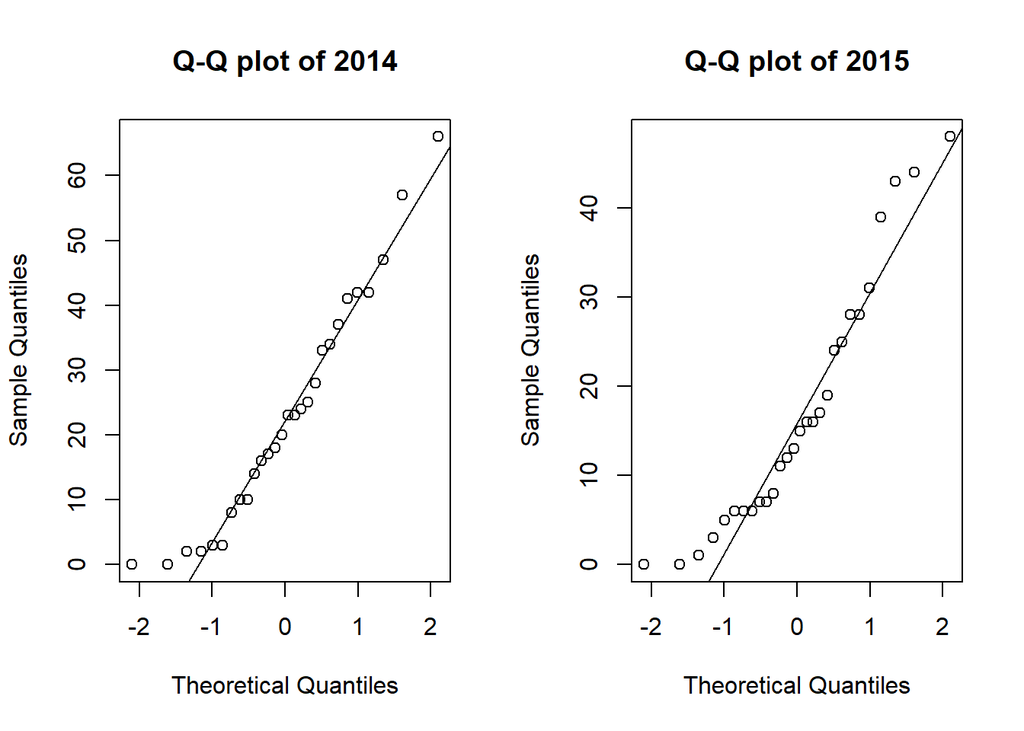

```r
par(mfrow=c(1,2))
qqnorm(data$diefstal_af_uit_woning_2014, main="Q-Q plot of 2014")
qqline(data$diefstal_af_uit_woning_2014)
qqnorm(data$diefstal_af_uit_woning_2015, main="Q-Q plot of 2015")
qqline(data$diefstal_af_uit_woning_2015)
```

It appears that the data from 2015 cannot be assumed to be normally distributed. We have to use a non-parametric alternative for the paired $t$-test.

### A non-parametric approach

A non-parametric alternative to the paired $t$-test, is the Wilcoxon signed-rank test. We use $a=0.05$. Our sample consists of 28 city districts. The hypotheses are as follows:

$H_0$: The median of the differences between burglary numbers is 0. There is no difference in the numbers between 2014 and 2015 ($\Delta \eta_{2014} = \Delta \eta_{2015}$).

$H_a$: The median of the differences between burglary numbers is not 0. There is a difference in the numbers between 2014 and 2015 ($\Delta \eta_{2014} \neq \Delta \eta_{2015}$).

```r
(w <- wilcox.test(data$diefstal_af_uit_woning_2014, data$diefstal_af_uit_woning_2015, paired = TRUE, alternative="two.sided"))
```

```
##
##  Wilcoxon signed rank test with continuity correction
##
## data:  data$diefstal_af_uit_woning_2014 and data$diefstal_af_uit_woning_2015
## V = 272.5, p-value = 0.003153
## alternative hypothesis: true location shift is not equal to 0
```

What is the effect size?

```r
library(effsize)
(cd <- cliff.delta(data$diefstal_af_uit_woning_2014, data$diefstal_af_uit_woning_2015))
```

```
##
## Cliff's Delta
##
## delta estimate: 0.1785714 (small)
## 95 percent confidence interval:
##      lower      upper
## -0.1339349  0.4587744
```

We tested whether there was a difference or not in the amount of statements involving burglary between 2014 and 2015. Our hypotheses were: $H_0: \Delta \eta_{2014} = \Delta \eta_{2015}$ and $H_a: \Delta \eta_{2014} \neq \Delta \eta_{2015}$. The amount of statements were obtained from the open data portal of the Municipality of Groningen. Since $\sigma$ is unknown and the samples were dependent, we conducted a Wilcoxon signed-rank test after verifying that the assumptions for the paired $t$-test were not met (data was not normally distributed, not more than 30 values). The mean amount of burglary statements in 2014 was 23.0357143, whereas it was 17.0714286 for 2015. The effect size was small (Cliff’s $\delta$: 0.1785714) and it reached significance at $a$-level 0.05: $V=272.5$, $p < 0.005$. We therefore reject the null hypothesis and accept the alternative hypothesis that there is a difference in burglary numbers between 2014 and 2015.

## Centre areas versus outer-centre areas

The next analysis involves a comparison of crime numbers between center areas and out-centre areas accross the period between 2014 and 2018. Before we continue, we create additional columns containing the total amount of statements per crime type.

```r
data$diefstal_af_uit_woning_totaal <-
  data$diefstal_af_uit_woning_2014 + data$diefstal_af_uit_woning_2015 +
  data$diefstal_af_uit_woning_2016 +
  data$diefstal_af_uit_woning_2017 +
  data$diefstal_af_uit_woning_2018

data$diefstal_auto_totaal <-
  data$diefstal_auto_2014 + data$diefstal_auto_2015 + data$diefstal_auto_2016 + data$diefstal_auto_2017 + data$diefstal_auto_2018

data$diefstal_fiets_totaal <-
  data$diefstal_fiets_2014 + data$diefstal_fiets_2015 + data$diefstal_fiets_2016 + data$diefstal_fiets_2017 + data$diefstal_fiets_2018

data$diefstal_af_uit_bedrijf_totaal <-
  data$diefstal_af_uit_bedrijf_2014 + data$diefstal_af_uit_bedrijf_2015 + data$diefstal_af_uit_bedrijf_2016 + data$diefstal_af_uit_bedrijf_2017 + data$diefstal_af_uit_bedrijf_2018

data$diefstal_af_uit_auto_totaal <-
  data$diefstal_af_uit_auto_2014 + data$diefstal_af_uit_auto_2015 + data$diefstal_af_uit_auto_2016 + data$diefstal_af_uit_auto_2017 + data$diefstal_af_uit_auto_2018

data$van_vernieling_totaal <-
  data$van_vernieling_2014 + data$van_vernieling_2015 + data$van_vernieling_2016 + data$van_vernieling_2017 + data$van_vernieling_2018

data$van_mishandeling_totaal <-
  data$van_mishandeling_2014 + data$van_mishandeling_2015 + data$van_mishandeling_2016 + data$van_mishandeling_2017 + data$van_mishandeling_2018
```

Due to the limited scope and time, we decide not to perform ANOVA-like calculations. Instead, we take a look per crime type and see what the differences are per area type.

### Housebreaking

We compare the numbers of the centre and outer-centre areas between 2014 and 2018.

```r
tapply(data$diefstal_af_uit_woning_totaal, data$area, FUN=sum)
```

```
##       centre outer_centre
##          609         1508
```

```r
tapply(data$diefstal_af_uit_woning_totaal, data$area, FUN=mean)
```

```
##       centre outer_centre
##       76.125       75.400
```

The majority of statements involving housebreaking can be found in the outer-centre areas. How is the distribution of these numbers?

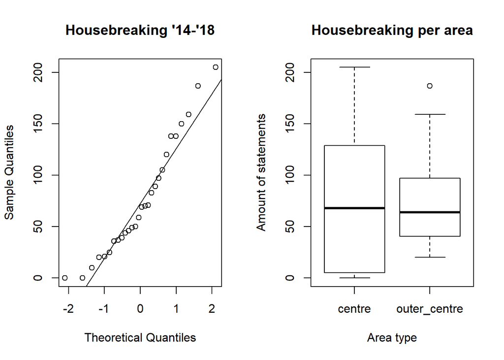

```r
par(mfrow=c(1,2))
qqnorm(data$diefstal_af_uit_woning_totaal, main="Housebreaking '14-'18")
qqline(data$diefstal_af_uit_woning_totaal)
boxplot(data$diefstal_af_uit_woning_totaal ~ data$area, main="Housebreaking per area", xlab="Area type", ylab="Amount of statements")
```

```r
shapiro.test(data$diefstal_af_uit_woning_totaal)
```

```
##
##  Shapiro-Wilk normality test
##
## data:  data$diefstal_af_uit_woning_totaal
## W = 0.93534, p-value = 0.08413
```

$H_0$: $\mu_{centre} = \mu_{outer-centre}$

$H_a$: $\mu_{centre} \neq \mu_{outer-centre}$

```r
t.test(diefstal_af_uit_woning_totaal ~ area, alternative = "two.sided", data = data)
```

```
##
##  Welch Two Sample t-test
##
## data:  diefstal_af_uit_woning_totaal by area
## t = 0.025079, df = 9.4201, p-value = 0.9805
## alternative hypothesis: true difference in means is not equal to 0
## 95 percent confidence interval:
##  -64.22841  65.67841
## sample estimates:
##       mean in group centre mean in group outer_centre
##                     76.125                     75.400
```

```r
library(effsize)
cohen.d(diefstal_af_uit_woning_totaal ~ area, data = data)
```

```
##
## Cohen's d
##
## d estimate: 0.01265522 (negligible)
## 95 percent confidence interval:
##      lower      upper
## -0.8472415  0.8725519
```

We tested whether the amount of police statements involving housebreaking from the centre areas were different from those of the outer-centre areas. Our hypotheses were: $H_0$: $\mu_{centre} = \mu_{outer-centre}$ and $H_a$: $\mu_{centre} \neq \mu_{outer-centre}$. Since $\sigma$ was unknown and the samples were independent, we conducted an independent samples $t$-test (corrected for unequal variances) after veryifing that the assumptions for the test were met (roughly normally distributed). The mean of the amount of police statements was 76.125 for the centre-areas and 75.400 for the outer-centre areas. The effect size was neglicible (Cohen’s $d$: $\approx$ 0.01265) and it reached significance at $a$-level 0.05: $t$(9.4201)=0.025, $p$ < 0.981. We therefore cannot reject the null hypothesis and accept that there is no difference between the amount of police statements involving housebreaking from both areas.

### Car theft

We compare the numbers of the centre and outer-centre areas between 2014 and 2018.

```r
tapply(data$diefstal_auto_totaal, data$area, FUN=sum)
```

```
##       centre outer_centre
##           43           83
```

```r
tapply(data$diefstal_auto_totaal, data$area, FUN=mean)
```

```
##       centre outer_centre
##        5.375        4.150
```

The majority of statements involving car theft can be found in the outer-centre areas. However, the mean amount of car thefts is higher in the city centre areas. How is the distribution of these numbers?

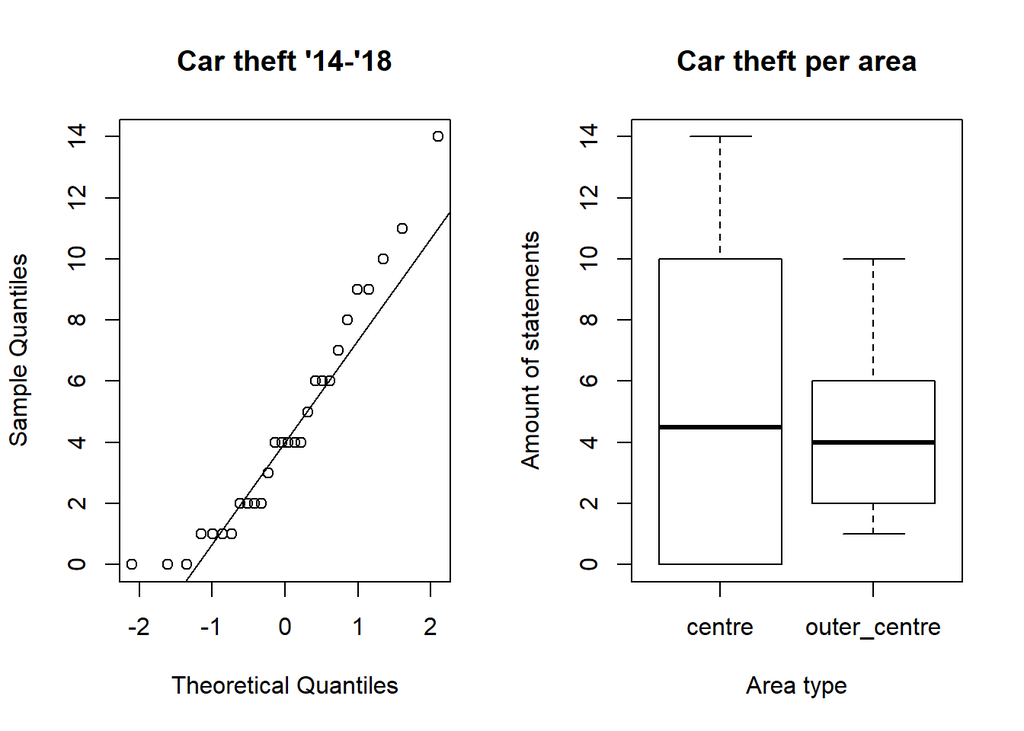

```r
par(mfrow=c(1,2))
qqnorm(data$diefstal_auto_totaal, main="Car theft '14-'18")
qqline(data$diefstal_auto_totaal)
boxplot(data$diefstal_auto_totaal ~ data$area, main="Car theft per area", xlab="Area type", ylab="Amount of statements")
```

```r
shapiro.test(data$diefstal_auto_totaal)
```

```
##
##  Shapiro-Wilk normality test
##
## data:  data$diefstal_auto_totaal
## W = 0.9236, p-value = 0.0426
```

$H_0$: $\mu_{centre} = \mu_{outer-centre}$

$H_a$: $\mu_{centre} \neq \mu_{outer-centre}$

```r
t.test(diefstal_auto_totaal ~ area, alternative = "two.sided", data = data)
```

```
##
##  Welch Two Sample t-test
##
## data:  diefstal_auto_totaal by area
## t = 0.57917, df = 8.1519, p-value = 0.5781
## alternative hypothesis: true difference in means is not equal to 0
## 95 percent confidence interval:
##  -3.636661  6.086661
## sample estimates:
##       mean in group centre mean in group outer_centre
##                      5.375                      4.150
```

```r
library(effsize)
cohen.d(diefstal_auto_totaal ~ area, data = data)
```

```
##
## Cohen's d
##
## d estimate: 0.3299314 (small)
## 95 percent confidence interval:
##      lower      upper
## -0.5347208  1.1945835
```

### Bicycle theft

We compare the numbers of the centre and outer-centre areas between 2014 and 2018.

```r
tapply(data$diefstal_fiets_totaal, data$area, FUN=sum)
```

```
##       centre outer_centre
##         5026         5833
```

```r
tapply(data$diefstal_fiets_totaal, data$area, FUN=mean)
```

```
##       centre outer_centre
##       628.25       291.65
```

The majority of statements involving bicycle theft can be found in the outer-centre areas. However, the mean amount of bicycle thefts is higher in the city centre areas. How is the distribution of these numbers?

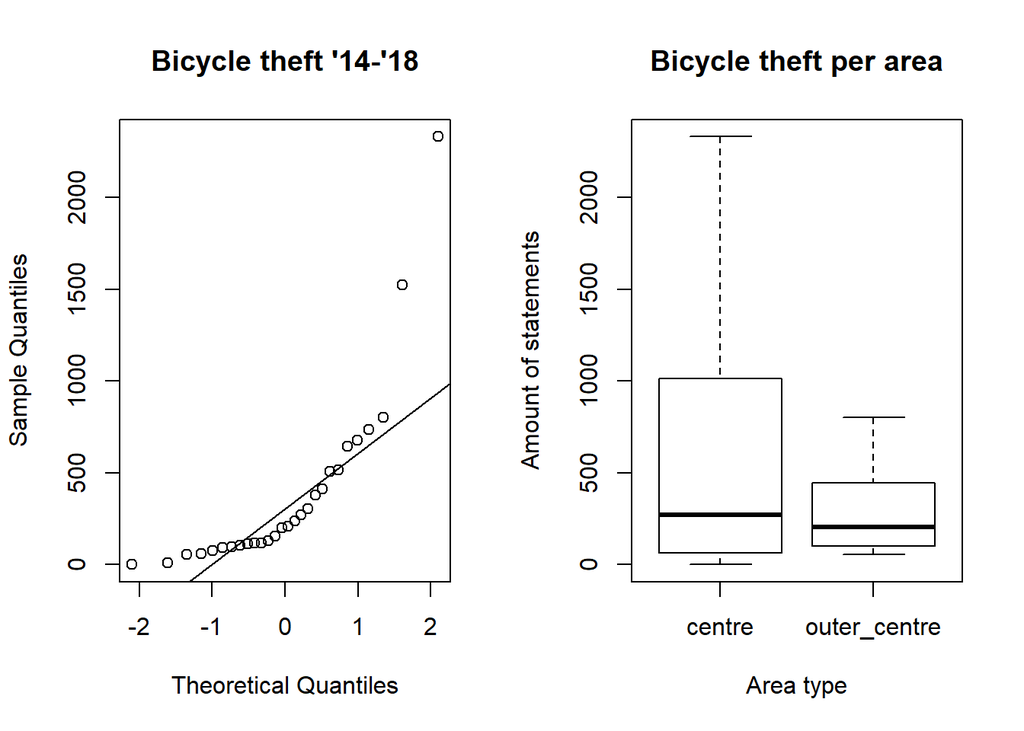

```r
par(mfrow=c(1,2))
qqnorm(data$diefstal_fiets_totaal, main="Bicycle theft '14-'18")
qqline(data$diefstal_fiets_totaal)
boxplot(data$diefstal_fiets_totaal ~ data$area, main="Bicycle theft per area", xlab="Area type", ylab="Amount of statements")
```

```r
shapiro.test(data$diefstal_fiets_totaal)
```

```
##
##  Shapiro-Wilk normality test
##
## data:  data$diefstal_fiets_totaal
## W = 0.68282, p-value = 1.644e-06
```

We cannot assume that the distribution of data is normal. We can therefore not perform a two-sided independent $t$-test and we have to perform the non-parametric Mann-Whitney U test. We use $a=0.05$, with $\mu_{centre}=628.25$ and $\mu_{outer-centre}=291.65$. Our hypotheses are:

$H_0$: $\mu_{centre} = \mu_{outer-centre}$

$H_a$: $\mu_{centre} \neq \mu_{outer-centre}$

```r
wilcox.test(diefstal_fiets_totaal ~ area, alternative = "two.sided", data = data)
```

```
##
##  Wilcoxon rank sum test
##
## data:  diefstal_fiets_totaal by area
## W = 85, p-value = 0.8227
## alternative hypothesis: true location shift is not equal to 0
```

```r
library(effsize)
cliff.delta(data$diefstal_fiets_totaal, data$area)
```

```
##
## Cliff's Delta
##
## delta estimate: 0.0625 (negligible)
## 95 percent confidence interval:
##      lower      upper
## -0.4749408  0.5659840
```

We tested whether the amount of police statements involving bicycle theft from the centre areas were different from those of the outer-centre areas. Our hypotheses were: $H_0$: $\mu_{centre} = \mu_{outer-centre}$ and $H_a$: $\mu_{centre} \neq \mu_{outer-centre}$. Since $\sigma$ was unknown and the samples were independent, we conducted a Mann-Whitney U test after veryifing that the assumptions for the test were not met (data was not normally distributed). The mean of the amount of police statements was 628.25 for the centre-areas and 291.65 for the outer-centre areas. The effect size was neglicible (Cliff’s $\delta$: $\approx$ 0.0625) and it reached significance at $a$-level 0.05: $W$=85, $p$ < 0.823. We therefore cannot reject the null hypothesis and accept that there is no difference between the amount of police statements involving bicycle theft from both areas.

### Business burglary

We compare the numbers of the centre and outer-centre areas between 2014 and 2018.

```r
tapply(data$diefstal_af_uit_bedrijf_totaal , data$area, FUN=sum)
```

```
##       centre outer_centre
##          501          373
```

```r
tapply(data$diefstal_af_uit_bedrijf_totaal , data$area, FUN=mean)
```

```
##       centre outer_centre
##       62.625       18.650
```

The majority of statements involving business burglary can be found in the centre areas. How is the distribution of these numbers?

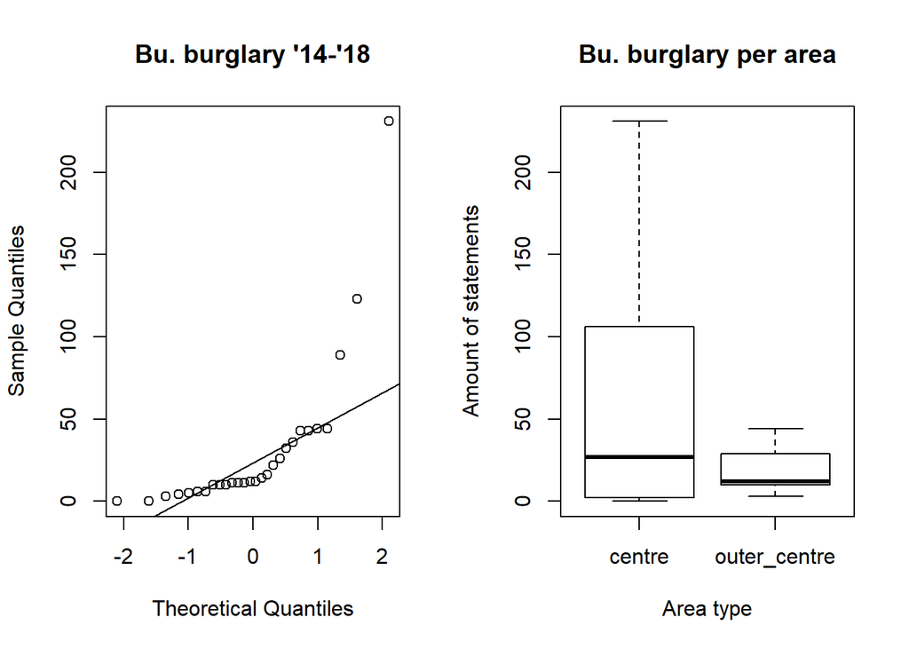

```r
par(mfrow=c(1,2))
qqnorm(data$diefstal_af_uit_bedrijf_totaal , main="Bu. burglary '14-'18")
qqline(data$diefstal_af_uit_bedrijf_totaal )
boxplot(data$diefstal_af_uit_bedrijf_totaal  ~ data$area, main="Bu. burglary per area", xlab="Area type", ylab="Amount of statements")
```

```r
shapiro.test(data$diefstal_af_uit_bedrijf_totaal )
```

```
##
##  Shapiro-Wilk normality test
##
## data:  data$diefstal_af_uit_bedrijf_totaal
## W = 0.59719, p-value = 1.345e-07
```

We cannot assume that the distribution of data is normal. We cannot therefore perform a two-sided independent $t$-test and we have to use the Man-Whitney U test als non-parametric alternative. We use $a=0.05$, with $\mu_{centre}=62.625$ and $\mu_{outer-centre}=18.650$. Our hypotheses are:

$H_0$: $\mu_{centre} = \mu_{outer-centre}$

$H_a$: $\mu_{centre} \neq \mu_{outer-centre}$

```r
wilcox.test(diefstal_af_uit_bedrijf_totaal  ~ area, alternative = "two.sided", data = data)
```

```
##
##  Wilcoxon rank sum test with continuity correction
##
## data:  diefstal_af_uit_bedrijf_totaal by area
## W = 86.5, p-value = 0.7599
## alternative hypothesis: true location shift is not equal to 0
```

```r
library(effsize)
cliff.delta(diefstal_af_uit_bedrijf_totaal  ~ area, data = data)
```

```
##
## Cliff's Delta
##
## delta estimate: 0.08125 (negligible)
## 95 percent confidence interval:
##      lower      upper
## -0.5158435  0.6252133
```

We tested whether the amount of police statements involving business burglary from the centre areas were different from those of the outer-centre areas. Our hypotheses were: $H_0$: $\mu_{centre} = \mu_{outer-centre}$ and $H_a$: $\mu_{centre} \neq \mu_{outer-centre}$. Since $\sigma$ was unknown and the samples were independent, we conducted a Mann-Whitney U test after veryifing that the assumptions for the test were not met (data was not normally distributed). The mean of the amount of police statements was 62.625 for the centre-areas and 18.650 for the outer-centre areas. The effect size was neglicible (Cliff’s $\delta$: $\approx$ 0.08125) and it reached significance at $a$-level 0.05: $W$=86.5, $p$ < 0.76. We therefore cannot reject the null hypothesis and accept that there is no difference between the amount of police statements involving business burglary from both areas.

### Theft from cars

We compare the numbers of the centre and outer-centre areas between 2014 and 2018.

```r
tapply(data$diefstal_af_uit_auto_totaal, data$area, FUN=sum)
```

```
##       centre outer_centre
##          609         1403
```

```r
tapply(data$diefstal_af_uit_auto_totaal, data$area, FUN=mean)
```

```
##       centre outer_centre
##       76.125       70.150
```

The majority of statements involving theft from cars can be found in the outer-centre areas, with the mean amount of thefts from cars being slightly higher in the centre areas. How is the distribution of these numbers?

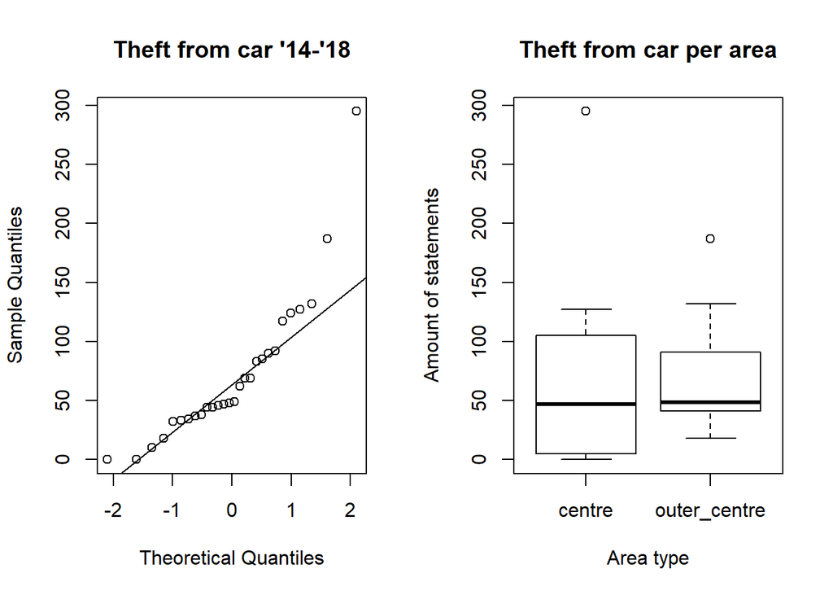

```r
par(mfrow=c(1,2))
qqnorm(data$diefstal_af_uit_auto_totaal, main="Theft from car '14-'18")
qqline(data$diefstal_af_uit_auto_totaal)
boxplot(data$diefstal_af_uit_auto_totaal ~ data$area, main="Theft from car per area", xlab="Area type", ylab="Amount of statements")
```

```r
shapiro.test(data$diefstal_af_uit_auto_totaal)
```

```
##
##  Shapiro-Wilk normality test
##
## data:  data$diefstal_af_uit_auto_totaal
## W = 0.8262, p-value = 0.0003208
```

We cannot assume that the distribution of data is normal. We cannot therefore perform a two-sided independent $t$-test and we have to use the non-parametric Mann-whitney U test. We use $a=0.05$, with $\mu_{centre}=76.125$ and $\mu_{outer-centre}=70.150$. Our hypotheses are:

$H_0$: $\mu_{centre} = \mu_{outer-centre}$

$H_a$: $\mu_{centre} \neq \mu_{outer-centre}$

```r
wilcox.test(diefstal_af_uit_auto_totaal ~ area, alternative = "two.sided", data = data)
```

```
##
##  Wilcoxon rank sum test with continuity correction
##
## data:  diefstal_af_uit_auto_totaal by area
## W = 63, p-value = 0.4012
## alternative hypothesis: true location shift is not equal to 0
```

```r
library(effsize)
cliff.delta(diefstal_af_uit_auto_totaal ~ area, data = data)
```

```
##
## Cliff's Delta
##
## delta estimate: -0.2125 (small)
## 95 percent confidence interval:
##      lower      upper
## -0.6854448  0.3865489
```

We tested whether the amount of police statements involving theft from cars from the centre areas were different from those of the outer-centre areas. Our hypotheses were: $H_0$: $\mu_{centre} = \mu_{outer-centre}$ and $H_a$: $\mu_{centre} \neq \mu_{outer-centre}$. Since $\sigma$ was unknown and the samples were independent, we conducted a Mann-Whitney U test after veryifing that the assumptions for the test were not met (data was not normally distributed). The mean of the amount of police statements was 76.125 for the centre-areas and 70.150 for the outer-centre areas. The effect size was small (Cliff’s $\delta$: $\approx$ -0.2125) and it reached significance at $a$-level 0.05: $W$=63, $p$ < 0.402. We therefore cannot reject the null hypothesis and accept that there is no difference between the amount of police statements involving theft from cars from both areas.

### Destruction

We compare the numbers of the centre and outer-centre areas between 2014 and 2018.

```r
tapply(data$van_vernieling_totaal, data$area, FUN=sum)
```

```
##       centre outer_centre
##         1163         2413
```

```r
tapply(data$van_vernieling_totaal, data$area, FUN=mean)
```

```
##       centre outer_centre
##      145.375      120.650
```

The majority of statements involving destruction can be found in the outer-centre areas, with the mean amount of destruction being higher in the centre areas. How is the distribution of these numbers?

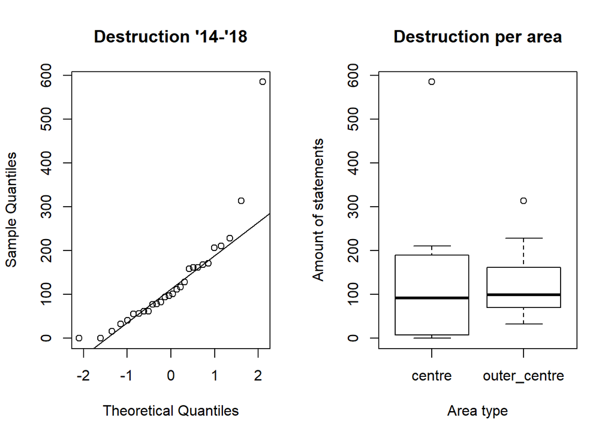

```r
par(mfrow=c(1,2))
qqnorm(data$van_vernieling_totaal , main="Destruction '14-'18")
qqline(data$van_vernieling_totaal )
boxplot(data$van_vernieling_totaal  ~ data$area, main="Destruction per area", xlab="Area type", ylab="Amount of statements")
```

```r
shapiro.test(data$van_vernieling_totaal )
```

```
##
##  Shapiro-Wilk normality test
##
## data:  data$van_vernieling_totaal
## W = 0.78399, p-value = 5.646e-05
```

$H_0$: $\mu_{centre} = \mu_{outer-centre}$

$H_a$: $\mu_{centre} \neq \mu_{outer-centre}$

```r
t.test(van_vernieling_totaal  ~ area, alternative = "two.sided", data = data)
```

```
##
##  Welch Two Sample t-test
##
## data:  van_vernieling_totaal by area
## t = 0.34986, df = 7.7563, p-value = 0.7358
## alternative hypothesis: true difference in means is not equal to 0
## 95 percent confidence interval:
##  -139.1388  188.5888
## sample estimates:
##       mean in group centre mean in group outer_centre
##                    145.375                    120.650
```

```r
library(effsize)
cohen.d(van_vernieling_totaal  ~ area, data = data)
```

```
##
## Cohen's d
##
## d estimate: 0.2097128 (small)
## 95 percent confidence interval:
##      lower      upper
## -0.6521041  1.0715298
```

### Abuse

We compare the numbers of the centre and outer-centre areas between 2014 and 2018.

```r
tapply(data$van_mishandeling_totaal , data$area, FUN=sum)
```

```
##       centre outer_centre
##         1637         1045
```

```r
tapply(data$van_mishandeling_totaal , data$area, FUN=mean)
```

```
##       centre outer_centre
##      204.625       52.250
```

The majority of statements involving abuse can be found in the centre areas. How is the distribution of these numbers?

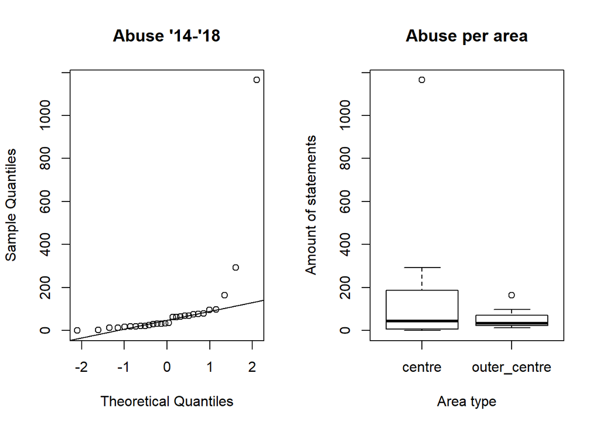

```r
par(mfrow=c(1,2))
qqnorm(data$van_mishandeling_totaal  , main="Abuse '14-'18")
qqline(data$van_mishandeling_totaal  )
boxplot(data$van_mishandeling_totaal ~ data$area, main="Abuse per area", xlab="Area type", ylab="Amount of statements")
```

```r
shapiro.test(data$van_mishandeling_totaal)
```

```
##
##  Shapiro-Wilk normality test
##
## data:  data$van_mishandeling_totaal
## W = 0.3754, p-value = 7.374e-10
```

We cannot assume that the distribution of data is normal. We cannot therefore perform a two-sided independent $t$-test and we have to use the non-parametric Mann-Whitney U test as alternative. We use $a=0.05$, with $\mu_{centre}=204.625$ and $\mu_{outer-centre}=52.250$. Our hypotheses are:

$H_0$: $\mu_{centre} = \mu_{outer-centre}$

$H_a$: $\mu_{centre} \neq \mu_{outer-centre}$

```r
wilcox.test(van_mishandeling_totaal ~ area, alternative = "two.sided", data = data)
```

```
##
##  Wilcoxon rank sum test with continuity correction
##
## data:  van_mishandeling_totaal by area
## W = 73.5, p-value = 0.7601
## alternative hypothesis: true location shift is not equal to 0
```

```r
library(effsize)
cliff.delta(van_mishandeling_totaal ~ area, data = data)
```

```
##
## Cliff's Delta
##
## delta estimate: -0.08125 (negligible)
## 95 percent confidence interval:
##      lower      upper
## -0.6272122  0.5182528
```

We tested whether the amount of police statements involving abuse from the centre areas were different from those of the outer-centre areas. Our hypotheses were: $H_0$: $\mu_{centre} = \mu_{outer-centre}$ and $H_a$: $\mu_{centre} \neq \mu_{outer-centre}$. Since $\sigma$ was unknown and the samples were independent, we conducted a Mann-Whitney U test after veryifing that the assumptions for the test were not met (data was not normally distributed). The mean of the amount of police statements was 204.625 for the centre-areas and 52.250 for the outer-centre areas. The effect size was negligible (cliff’s $\delta$: $\approx$ -0.08125) and it reached significance at $a$-level 0.05: $W$=73.5, $p$ < 0.761. We therefore cannot reject the null hypothesis and accept that there is no difference between the amount of police statements involving abuse from both areas.